# HCAIM Deep Learinng Module - CA1

- Wan Yit Yong (X00205680)

### Introduction

```python
# import libraries
import pandas as pd
import numpy as np
import seaborn as sns
import matplotlib.pyplot as plt
import tensorflow as tf

from sklearn import*
from tensorflow import keras

# sklearn 10FCV
from sklearn.model_selection import KFold
from sklearn.preprocessing import LabelEncoder
from sklearn.model_selection import cross_val_score
from sklearn.model_selection import cross_val_predict
from sklearn.model_selection import train_test_split
from sklearn.metrics import confusion_matrix
from sklearn.model_selection import GridSearchCV

# Keras
from tensorflow import keras
from tensorflow.keras.layers import Dense
from tensorflow.keras.models import Sequential
from tensorflow.keras.layers import SpatialDropout3D
from tensorflow.keras.layers import Dropout
from tensorflow.keras.layers import GaussianNoise
from tensorflow.keras.callbacks import ModelCheckpoint
from tensorflow.keras.callbacks import EarlyStopping
from tensorflow.keras.wrappers.scikit_learn import KerasClassifier

seed = 1
np.random.seed(seed)

plt.rcParams["figure.figsize"] = (15,5)
```

### Opening the dataset, brief data exploration and data pre-processing

```python
# Read the csv file
data = pd.read_csv("X00205680.csv")
data.head(5)
```

|  | HighBP | HighChol | CholCheck | BMI | Smoker | Stroke | HeartDiseaseorAttack | PhysActivity | Fruits | Veggies | ... | NoDocbcCost | GenHlth | MentHlth | PhysHlth | DiffWalk | Sex | Age | Education | Income | Diabetes_binary |
| --- | --- | --- | --- | --- | --- | --- | --- | --- | --- | --- | --- | --- | --- | --- | --- | --- | --- | --- | --- | --- | --- |
| 0 | 0 | 1 | 1 | 22 | 1 | 0 | 0 | 1 | 1 | 1 | ... | 0 | 1 | 0 | 0 | 0 | 1 | 11 | 6 | 7 | 0 |
| 1 | 0 | 1 | 1 | 23 | 1 | 0 | 0 | 0 | 0 | 1 | ... | 0 | 4 | 0 | 3 | 1 | 0 | 8 | 4 | 7 | 0 |
| 2 | 0 | 1 | 1 | 25 | 1 | 0 | 0 | 1 | 0 | 1 | ... | 0 | 2 | 0 | 0 | 0 | 1 | 9 | 4 | 8 | 1 |
| 3 | 0 | 0 | 1 | 19 | 0 | 0 | 0 | 0 | 1 | 1 | ... | 0 | 2 | 0 | 0 | 0 | 1 | 4 | 6 | 8 | 0 |
| 4 | 1 | 0 | 1 | 29 | 1 | 0 | 0 | 1 | 1 | 1 | ... | 0 | 3 | 0 | 0 | 0 | 0 | 9 | 4 | 7 | 1 |

5 rows × 22 columns

```python
data.describe().T
```

|  | count | mean | std | min | 25% | 50% | 75% | max |
| --- | --- | --- | --- | --- | --- | --- | --- | --- |
| HighBP | 42415.0 | 0.563904 | 0.495905 | 0.0 | 0.0 | 1.0 | 1.0 | 1.0 |
| HighChol | 42415.0 | 0.527526 | 0.499248 | 0.0 | 0.0 | 1.0 | 1.0 | 1.0 |
| CholCheck | 42415.0 | 0.975221 | 0.155453 | 0.0 | 1.0 | 1.0 | 1.0 | 1.0 |
| BMI | 42415.0 | 29.892727 | 7.130757 | 13.0 | 25.0 | 29.0 | 33.0 | 98.0 |
| Smoker | 42415.0 | 0.476482 | 0.499453 | 0.0 | 0.0 | 0.0 | 1.0 | 1.0 |
| Stroke | 42415.0 | 0.062054 | 0.241256 | 0.0 | 0.0 | 0.0 | 0.0 | 1.0 |
| HeartDiseaseorAttack | 42415.0 | 0.148391 | 0.355491 | 0.0 | 0.0 | 0.0 | 0.0 | 1.0 |
| PhysActivity | 42415.0 | 0.701898 | 0.457430 | 0.0 | 0.0 | 1.0 | 1.0 | 1.0 |
| Fruits | 42415.0 | 0.614476 | 0.486725 | 0.0 | 0.0 | 1.0 | 1.0 | 1.0 |
| Veggies | 42415.0 | 0.789320 | 0.407796 | 0.0 | 1.0 | 1.0 | 1.0 | 1.0 |
| HvyAlcoholConsump | 42415.0 | 0.042886 | 0.202602 | 0.0 | 0.0 | 0.0 | 0.0 | 1.0 |
| AnyHealthcare | 42415.0 | 0.953366 | 0.210857 | 0.0 | 1.0 | 1.0 | 1.0 | 1.0 |
| NoDocbcCost | 42415.0 | 0.094683 | 0.292781 | 0.0 | 0.0 | 0.0 | 0.0 | 1.0 |
| GenHlth | 42415.0 | 2.835129 | 1.116647 | 1.0 | 2.0 | 3.0 | 4.0 | 5.0 |
| MentHlth | 42415.0 | 3.741530 | 8.132504 | 0.0 | 0.0 | 0.0 | 2.0 | 30.0 |
| PhysHlth | 42415.0 | 5.834304 | 10.086633 | 0.0 | 0.0 | 0.0 | 6.0 | 30.0 |
| DiffWalk | 42415.0 | 0.253000 | 0.434736 | 0.0 | 0.0 | 0.0 | 1.0 | 1.0 |
| Sex | 42415.0 | 0.459083 | 0.498329 | 0.0 | 0.0 | 0.0 | 1.0 | 1.0 |
| Age | 42415.0 | 8.571708 | 2.846738 | 1.0 | 7.0 | 9.0 | 11.0 | 13.0 |
| Education | 42415.0 | 4.920406 | 1.027207 | 1.0 | 4.0 | 5.0 | 6.0 | 6.0 |
| Income | 42415.0 | 5.704020 | 2.175041 | 1.0 | 4.0 | 6.0 | 8.0 | 8.0 |
| Diabetes_binary | 42415.0 | 0.500672 | 0.500005 | 0.0 | 0.0 | 1.0 | 1.0 | 1.0 |

```python
print("The size of the data is (in KB):", data.size)
print("The shape of the data is (Rows x Columns):", data.shape)
print(data.columns)
```

```
The size of the data is (in KB): 933130
The shape of the data is (Rows x Columns): (42415, 22)
Index(['HighBP', 'HighChol', 'CholCheck', 'BMI', 'Smoker', 'Stroke',
       'HeartDiseaseorAttack', 'PhysActivity', 'Fruits', 'Veggies',
       'HvyAlcoholConsump', 'AnyHealthcare', 'NoDocbcCost', 'GenHlth',
       'MentHlth', 'PhysHlth', 'DiffWalk', 'Sex', 'Age', 'Education', 'Income',
       'Diabetes_binary'],
      dtype='object')
```

```python
# Check the data variable types
data.info()
```

```
<class 'pandas.core.frame.DataFrame'>
RangeIndex: 42415 entries, 0 to 42414
Data columns (total 22 columns):
 #   Column                Non-Null Count  Dtype
---  ------                --------------  -----
 0   HighBP                42415 non-null  int64
 1   HighChol              42415 non-null  int64
 2   CholCheck             42415 non-null  int64
 3   BMI                   42415 non-null  int64
 4   Smoker                42415 non-null  int64
 5   Stroke                42415 non-null  int64
 6   HeartDiseaseorAttack  42415 non-null  int64
 7   PhysActivity          42415 non-null  int64
 8   Fruits                42415 non-null  int64
 9   Veggies               42415 non-null  int64
 10  HvyAlcoholConsump     42415 non-null  int64
 11  AnyHealthcare         42415 non-null  int64
 12  NoDocbcCost           42415 non-null  int64
 13  GenHlth               42415 non-null  int64
 14  MentHlth              42415 non-null  int64
 15  PhysHlth              42415 non-null  int64
 16  DiffWalk              42415 non-null  int64
 17  Sex                   42415 non-null  int64
 18  Age                   42415 non-null  int64
 19  Education             42415 non-null  int64
 20  Income                42415 non-null  int64
 21  Diabetes_binary       42415 non-null  int64
dtypes: int64(22)
memory usage: 7.1 MB
```

```python
# Check any empty / missing data
data.isnull().sum()
```

```
HighBP                  0
HighChol                0
CholCheck               0
BMI                     0
Smoker                  0
Stroke                  0
HeartDiseaseorAttack    0
PhysActivity            0
Fruits                  0
Veggies                 0
HvyAlcoholConsump       0
AnyHealthcare           0
NoDocbcCost             0
GenHlth                 0
MentHlth                0
PhysHlth                0
DiffWalk                0
Sex                     0
Age                     0
Education               0
Income                  0
Diabetes_binary         0
dtype: int64
```

```python
data.duplicated().sum()
```

```
703
```

```python
data.loc[data.duplicated(),:]
```

|  | HighBP | HighChol | CholCheck | BMI | Smoker | Stroke | HeartDiseaseorAttack | PhysActivity | Fruits | Veggies | ... | NoDocbcCost | GenHlth | MentHlth | PhysHlth | DiffWalk | Sex | Age | Education | Income | Diabetes_binary |
| --- | --- | --- | --- | --- | --- | --- | --- | --- | --- | --- | --- | --- | --- | --- | --- | --- | --- | --- | --- | --- | --- |
| 1019 | 0 | 1 | 1 | 26 | 0 | 0 | 0 | 1 | 1 | 1 | ... | 0 | 2 | 0 | 0 | 0 | 1 | 7 | 6 | 8 | 0 |
| 1535 | 0 | 0 | 1 | 38 | 0 | 0 | 0 | 1 | 1 | 1 | ... | 0 | 3 | 0 | 0 | 0 | 1 | 7 | 6 | 8 | 0 |
| 1963 | 0 | 0 | 1 | 22 | 0 | 0 | 0 | 1 | 1 | 1 | ... | 0 | 2 | 0 | 0 | 0 | 0 | 7 | 6 | 8 | 0 |
| 2279 | 1 | 0 | 1 | 31 | 0 | 0 | 0 | 1 | 0 | 1 | ... | 0 | 3 | 0 | 0 | 0 | 1 | 11 | 6 | 7 | 1 |
| 2301 | 1 | 1 | 1 | 26 | 1 | 0 | 0 | 1 | 1 | 1 | ... | 0 | 3 | 0 | 0 | 0 | 1 | 11 | 6 | 8 | 1 |
| ... | ... | ... | ... | ... | ... | ... | ... | ... | ... | ... | ... | ... | ... | ... | ... | ... | ... | ... | ... | ... | ... |
| 42196 | 0 | 0 | 1 | 21 | 1 | 0 | 0 | 1 | 1 | 1 | ... | 0 | 1 | 0 | 0 | 0 | 0 | 4 | 6 | 8 | 0 |
| 42212 | 1 | 0 | 1 | 25 | 0 | 0 | 0 | 1 | 1 | 1 | ... | 0 | 1 | 0 | 0 | 0 | 1 | 7 | 6 | 8 | 0 |
| 42264 | 1 | 1 | 1 | 32 | 1 | 0 | 0 | 1 | 1 | 1 | ... | 0 | 3 | 0 | 0 | 0 | 1 | 9 | 5 | 7 | 1 |
| 42303 | 0 | 0 | 1 | 32 | 0 | 0 | 0 | 1 | 1 | 1 | ... | 0 | 2 | 0 | 0 | 0 | 0 | 4 | 6 | 8 | 0 |
| 42390 | 1 | 1 | 1 | 26 | 0 | 0 | 0 | 1 | 1 | 1 | ... | 0 | 3 | 0 | 2 | 0 | 1 | 7 | 6 | 8 | 1 |

703 rows × 22 columns

```python
print("The shape of the data before is (Rows x Columns):", data.shape)
data.drop_duplicates(inplace=True)
print("The shape of the data after is (Rows x Columns):", data.shape)
```

```
The shape of the data before is (Rows x Columns): (42415, 22)
The shape of the data after is (Rows x Columns): (41712, 22)
```

```python
data['Diabetes_binary'].value_counts()
```

```
1    21135
0    20577
Name: Diabetes_binary, dtype: int64
```

*0 - No Diabetes*

*1 - Diabetes*

After checking and removing the missing (null) and duplicate data, so we don't need to fill up or drop any data. Besides that, all columns are numerical number so we also don't need to do any label encoder or get_dummies (one-hot encoding). So for the next step in pre-processing will be split the data into X and Y dataset which seperate the label class from others. Besides that, we will also normalised the data before start putting into Deep Learning models.

```python
col = data.values

X = col[:, 0:21]
Y = col[:, 21]

print("Before Normalized: \n", X)

scaler = preprocessing.Normalizer().fit(X)
normalizedX = scaler.transform(X)

print("\nAfter Normalized: \n", normalizedX)
```

```
Before Normalized:
 [[ 0  1  1 ... 11  6  7]
 [ 0  1  1 ...  8  4  7]
 [ 0  1  1 ...  9  4  8]
 ...
 [ 1  0  1 ... 11  6  7]
 [ 1  1  1 ... 10  5  8]
 [ 0  0  1 ...  1  5  3]]

After Normalized:
 [[0.         0.03782347 0.03782347 ... 0.41605821 0.22694084 0.26476432]
 [0.         0.03809697 0.03809697 ... 0.30477573 0.15238786 0.26667876]
 [0.         0.03542182 0.03542182 ... 0.31879636 0.14168727 0.28337454]
 ...
 [0.0256579  0.         0.0256579  ... 0.2822369  0.1539474  0.1796053 ]
 [0.02400768 0.02400768 0.02400768 ... 0.24007684 0.12003842 0.19206147]
 [0.         0.         0.04559608 ... 0.04559608 0.22798038 0.13678823]]
```

After normalized the X data, we will now able to split the X and Y data into train and test for further machine learning.

```python
X_train, X_test, Y_train, Y_test  = train_test_split(normalizedX, Y, test_size=0.33, random_state=seed, shuffle = True, stratify=(Y))


# Examine the class breakdown per dataset:
print("Training dataset length:", len(X_train))
print("Testing dataset length:", len(X_test))

class1TrainingPer = np.count_nonzero(Y_train == 1) / len(X_train)
class1TestPer = np.count_nonzero(Y_test == 1) / len(X_test)

print("\nPercentage of 1's in Training data: ", round(class1TrainingPer*100,2), "%")
print("Percentage of 1's in Test data    : ", round(class1TestPer*100,2), "%")
```

```
Training dataset length: 27947
Testing dataset length: 13765

Percentage of 1's in Training data:  50.67 %
Percentage of 1's in Test data    :  50.67 %
```

From the description above, we know that the dataset for training and testing contains almost equal (50%) between the 0 and 1 label which will given a better outcome after the machine learning model implement. Before moving to the next step, ;et see the heatmap for this dataset so we can observed which columns are highly related and which are not.

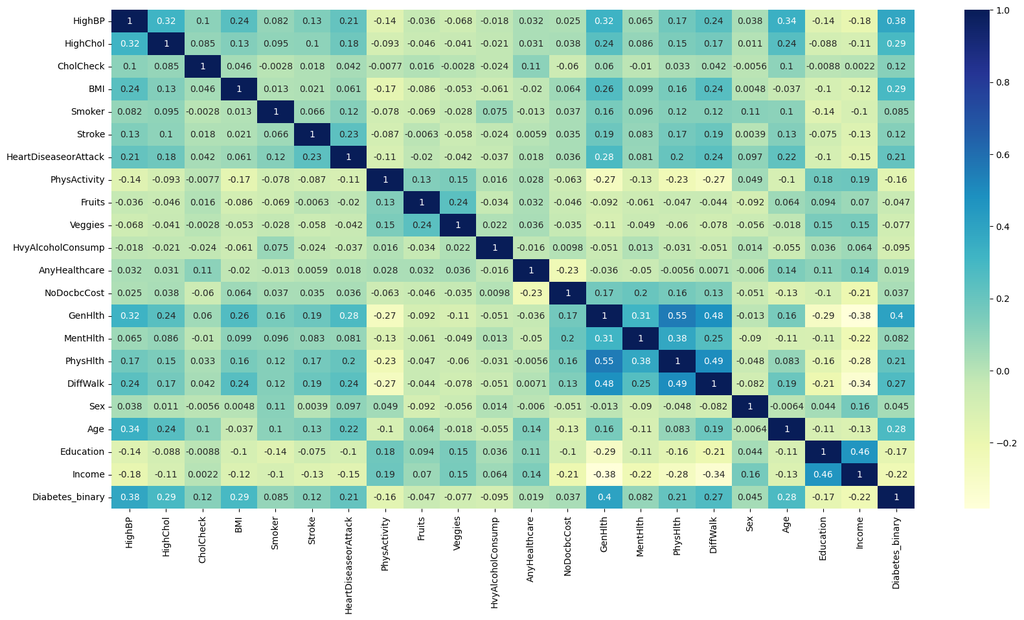

```python
plt.figure(figsize=(20,10))
sns.heatmap(data.corr(), annot=True, cmap="YlGnBu")
```

From the heatmap above, we notice that most of the attributes are not highly correlated with the 'Diabetes_binary'. The highest correlated attribute is 'GenHlth', coming up with 'HighBP' which stand for 'General Health' and 'High Blood Preasure'.

### Model Exploration to determine network topology

- 8 required

```python
# Funtion to provide plot for loss and accuracy
def plot_acc_loss(results):
  plt.subplot(1,2,1)
  # summarize history for loss
  plt.plot(results.history['loss'])
  plt.title('model loss')
  plt.ylabel('loss')
  plt.xlabel('epoch')
  plt.legend(['train', 'test'], loc='upper left')

  plt.subplot(1,2,2)
  plt.plot(results.history['acc'])
  plt.title('model accuracy')
  plt.ylabel('acc')
  plt.xlabel('epoch')
  plt.legend(['train', 'test'], loc='upper left')
  plt.show()
```

#### Build the model (relative large)

```
Train on 27947 samples
```

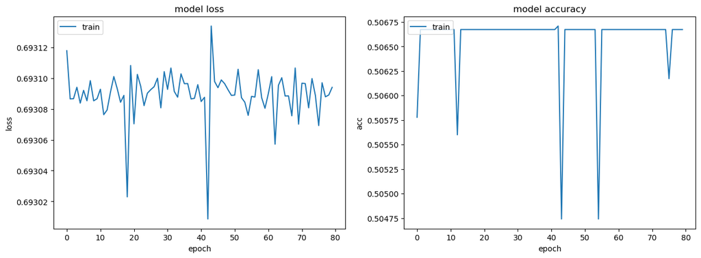

```
Acuracy:  0.50671995
Predicted      1    All
Actual
0           6790   6790
1           6975   6975
All        13765  13765
```

```python
seed = 1
np.random.seed(seed)
tf.random.set_seed(seed)

model = Sequential()
model.add(Dense(1000, input_dim = 21, activation='relu'))
model.add(Dense(100, activation='relu'))
model.add(Dense(50, activation='relu'))
model.add(Dense(5, activation='relu'))
model.add(Dense(1, activation='sigmoid'))

model.compile(loss='binary_crossentropy', optimizer="adam", metrics=['acc'])
results = model.fit(X_train, Y_train, epochs=80, batch_size=32, verbose=1)

plot_acc_loss(results)

# generate predictions from text data
dl_y_pred = (model.predict(X_test) > 0.5).astype("int32")
dl_y_pred = dl_y_pred.flatten()

# Confusion Matrix:
# overall TP, FP, TN, FN values, for binary values only
print("Acuracy: ", model.evaluate(X_test,Y_test)[1])
print(pd.crosstab(Y_test, dl_y_pred, rownames=['Actual'], colnames=['Predicted'], margins=True))
```

#### Build the model (relative large - medium)

```
Train on 27947 samples
```

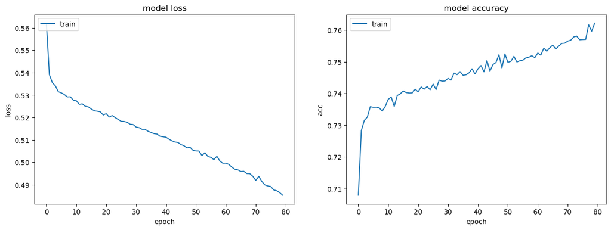

```
Acuracy:  0.7336724
Predicted     0     1    All
Actual
0          4498  2292   6790
1          1374  5601   6975
All        5872  7893  13765
```

```python
seed = 1
np.random.seed(seed)
tf.random.set_seed(seed)

model = Sequential()
model.add(Dense(500, input_dim = 21, activation='relu'))
model.add(Dense(100, activation='relu'))
model.add(Dense(50, activation='relu'))
model.add(Dense(1, activation='sigmoid'))

model.compile(loss='binary_crossentropy', optimizer="adam", metrics=['acc'])
results = model.fit(X_train, Y_train, epochs=80, batch_size=32, verbose=1)

plot_acc_loss(results)

# generate predictions from text data
dl_y_pred = (model.predict(X_test) > 0.5).astype("int32")
dl_y_pred = dl_y_pred.flatten()

# Confusion Matrix:
# overall TP, FP, TN, FN values, for binary values only
print("Acuracy: ", model.evaluate(X_test,Y_test)[1])
print(pd.crosstab(Y_test, dl_y_pred, rownames=['Actual'], colnames=['Predicted'], margins=True))
```

#### Build the model (relative medium)

```
Train on 27947 samples
```

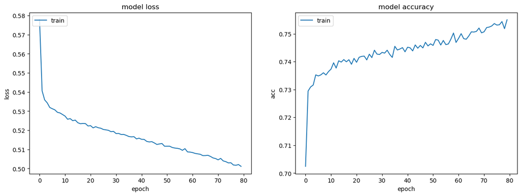

```
Acuracy:  0.73774064
Predicted     0     1    All
Actual
0          4715  2075   6790
1          1535  5440   6975
All        6250  7515  13765
```

```python
seed = 1
np.random.seed(seed)
tf.random.set_seed(seed)

model = Sequential()
model.add(Dense(100, input_dim = 21, activation='relu'))
model.add(Dense(50, activation='relu'))
model.add(Dense(5, activation='relu'))
model.add(Dense(1, activation='sigmoid'))

model.compile(loss='binary_crossentropy', optimizer="adam", metrics=['acc'])
results = model.fit(X_train, Y_train, epochs=80, batch_size=32, verbose=1)

plot_acc_loss(results)

# generate predictions from text data
dl_y_pred = (model.predict(X_test) > 0.5).astype("int32")
dl_y_pred = dl_y_pred.flatten()

# Confusion Matrix:
# overall TP, FP, TN, FN values, for binary values only
print("Acuracy: ", model.evaluate(X_test,Y_test)[1])
print(pd.crosstab(Y_test, dl_y_pred, rownames=['Actual'], colnames=['Predicted'], margins=True))
```

#### Build the model (relative medium - small)

```
Train on 27947 samples
```

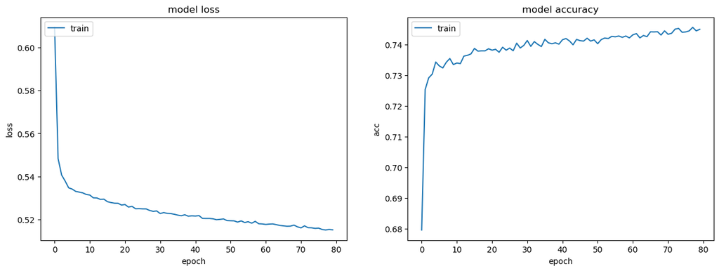

```
Acuracy:  0.7367236
Predicted     0     1    All
Actual
0          4490  2300   6790
1          1324  5651   6975
All        5814  7951  13765
```

```python
seed = 1
np.random.seed(seed)
tf.random.set_seed(seed)

model = Sequential()
model.add(Dense(50, input_dim = 21, activation='relu'))
model.add(Dense(5, activation='relu'))
model.add(Dense(1, activation='sigmoid'))

model.compile(loss='binary_crossentropy', optimizer="adam", metrics=['acc'])
results = model.fit(X_train, Y_train, epochs=80, batch_size=32, verbose=1)

plot_acc_loss(results)

# generate predictions from text data
dl_y_pred = (model.predict(X_test) > 0.5).astype("int32")
dl_y_pred = dl_y_pred.flatten()


# Confusion Matrix:
# overall TP, FP, TN, FN values, for binary values only
print("Acuracy: ", model.evaluate(X_test,Y_test)[1])
print(pd.crosstab(Y_test, dl_y_pred, rownames=['Actual'], colnames=['Predicted'], margins=True))
```

#### Building the model (relative small)

```
Train on 27947 samples
```

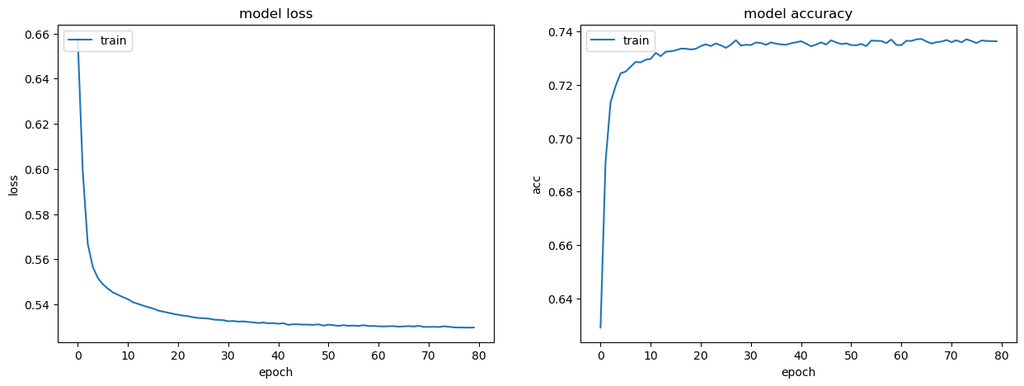

```
Acuracy:  0.7299673
Predicted     0     1    All
Actual
0          4590  2200   6790
1          1517  5458   6975
All        6107  7658  13765
```

```python
seed = 1
np.random.seed(seed)
tf.random.set_seed(seed)

model = Sequential()
model.add(Dense(10, input_dim = 21, activation='relu'))
model.add(Dense(1, activation='sigmoid'))

model.compile(loss='binary_crossentropy', optimizer="adam", metrics=['acc'])
results = model.fit(X_train, Y_train, epochs=80, batch_size=32, verbose=1)

plot_acc_loss(results)

# generate predictions from text data
dl_y_pred = (model.predict(X_test) > 0.5).astype("int32")
dl_y_pred = dl_y_pred.flatten()

# Confusion Matrix:
# overall TP, FP, TN, FN values, for binary values only
print("Acuracy: ", model.evaluate(X_test,Y_test)[1])
print(pd.crosstab(Y_test, dl_y_pred, rownames=['Actual'], colnames=['Predicted'], margins=True))
```

From the test above from the models, we noticed that the small to medium model is perform way better than the large model. This might because of the correlation between attributes and the label class is not highly correlated, so the model will work better with small model. So for further testing, we will keep tuning in medium to small network.

#### Further testing - between small and small - medium

```
Train on 27947 samples
```

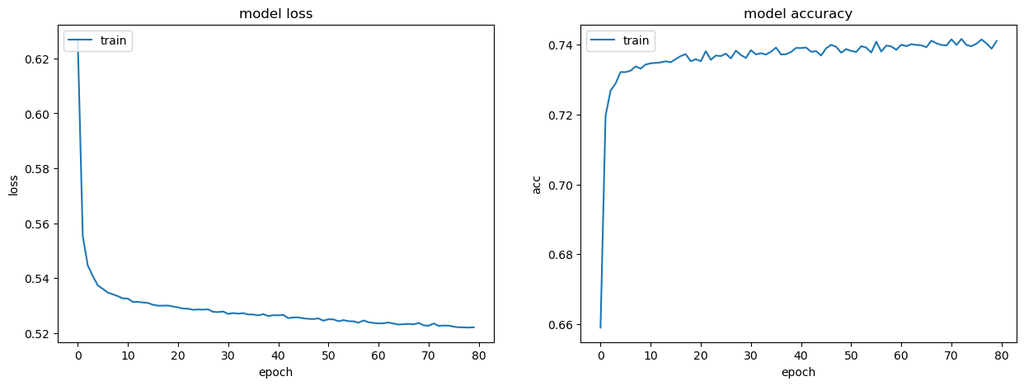

```
Acuracy:  0.7375954
Predicted     0     1    All
Actual
0          4567  2223   6790
1          1389  5586   6975
All        5956  7809  13765
```

```python
seed = 1
np.random.seed(seed)
tf.random.set_seed(seed)

model = Sequential()
model.add(Dense(20, input_dim = 21, activation='relu'))
model.add(Dense(5, activation='relu'))
model.add(Dense(1, activation='sigmoid'))

model.compile(loss='binary_crossentropy', optimizer="adam", metrics=['acc'])
results = model.fit(X_train, Y_train, epochs=80, batch_size=32, verbose=1)

plot_acc_loss(results)

# generate predictions from text data
dl_y_pred = (model.predict(X_test) > 0.5).astype("int32")
dl_y_pred = dl_y_pred.flatten()

# Confusion Matrix:
# overall TP, FP, TN, FN values, for binary values only
print("Acuracy: ", model.evaluate(X_test,Y_test)[1])
print(pd.crosstab(Y_test, dl_y_pred, rownames=['Actual'], colnames=['Predicted'], margins=True))
```

Compare the result with small, the performance almost the same, maybe we can try with different number

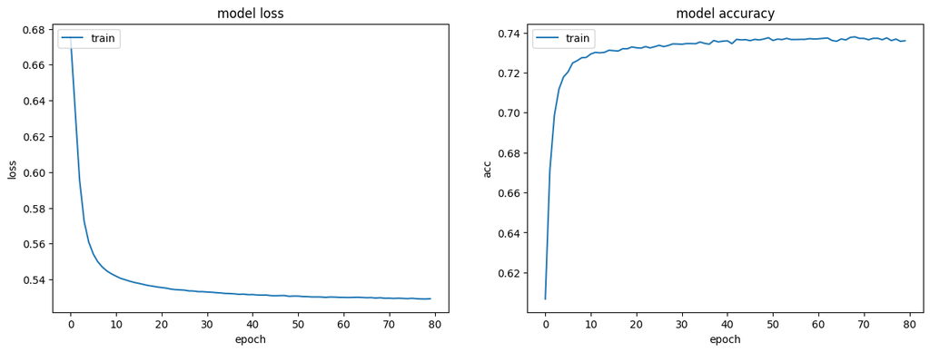

```
Acuracy:  0.7325826287269592
Predicted     0     1    All
Actual
0          4656  2134   6790
1          1547  5428   6975
All        6203  7562  13765
```

```python
seed = 1
np.random.seed(seed)
tf.random.set_seed(seed)

model = Sequential()
model.add(Dense(5, input_dim = 21, activation='relu'))
model.add(Dense(1, activation='sigmoid'))

model.compile(loss='binary_crossentropy', optimizer="adam", metrics=['acc'])
results = model.fit(X_train, Y_train, epochs=80, batch_size=32, verbose=1)

plot_acc_loss(results)

# generate predictions from text data
dl_y_pred = (model.predict(X_test) > 0.5).astype("int32")
dl_y_pred = dl_y_pred.flatten()

# Confusion Matrix:
# overall TP, FP, TN, FN values, for binary values only
print("Acuracy: ", model.evaluate(X_test,Y_test)[1])
print(pd.crosstab(Y_test, dl_y_pred, rownames=['Actual'], colnames=['Predicted'], margins=True))
```

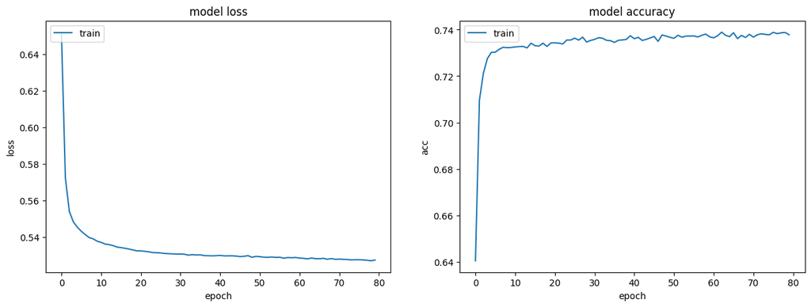

```
Acuracy:  0.7282963991165161
Predicted     0     1    All
Actual
0          4938  1852   6790
1          1888  5087   6975
All        6826  6939  13765
```

```python
seed = 1
np.random.seed(seed)
tf.random.set_seed(seed)

model = Sequential()
model.add(Dense(5, input_dim = 21, activation='relu'))
model.add(Dense(3, activation='relu'))
model.add(Dense(1, activation='sigmoid'))

model.compile(loss='binary_crossentropy', optimizer="adam", metrics=['acc'])
results = model.fit(X_train, Y_train, epochs=80, batch_size=32, verbose=1)

plot_acc_loss(results)

# generate predictions from text data
dl_y_pred = (model.predict(X_test) > 0.5).astype("int32")
dl_y_pred = dl_y_pred.flatten()

# Confusion Matrix:
# overall TP, FP, TN, FN values, for binary values only
print("Acuracy: ", model.evaluate(X_test,Y_test)[1])
print(pd.crosstab(Y_test, dl_y_pred, rownames=['Actual'], colnames=['Predicted'], margins=True))
```

After some tweaking on the layers, the results showed that the accuracy is around 73%. So i'll use the last neural network as it got the highest accuracy on no diabetes which is 4938 / 6790.

### Hyperparameter investigation

- 8 batch sizes [suitable epochs]
- 3 optimizers
- 2 or more regularization techniques

```python
# Funtion to provide plot for loss and accuracy
def plot_acc_loss2(results):
  plt.subplot(1,2,1)
  # summarize history for loss
  plt.plot(results.history['loss'])
  plt.plot(results.history['val_loss'])
  plt.title('Model Loss ')
  plt.ylabel('loss')
  plt.xlabel('epoch')
  plt.legend(['train', 'test'], loc='upper left')

  plt.subplot(1,2,2)
  plt.plot(results.history['acc'])
  plt.plot(results.history['val_acc'])
  plt.title('Model Accuracy')
  plt.ylabel('acc')
  plt.xlabel('epoch')
  plt.legend(['train', 'test'], loc='upper left')
  plt.show()
```

#### Trying with different batch sizes and epochs.

- During the model was testing with different capacity and depth, the model were trained with batch sizes = 32. So we will tried other here.

```
 ************************ Testing ************************
Batch Size :  1
Epoch:  5
```

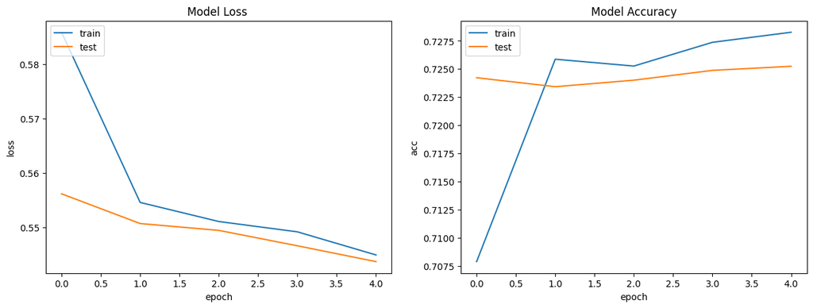

```
Acuracy:  0.7252451777458191
Predicted     0     1    All
Actual
0          4709  2081   6790
1          1701  5274   6975
All        6410  7355  13765
 ************************ Testing ************************
Batch Size :  8
Epoch:  30
```

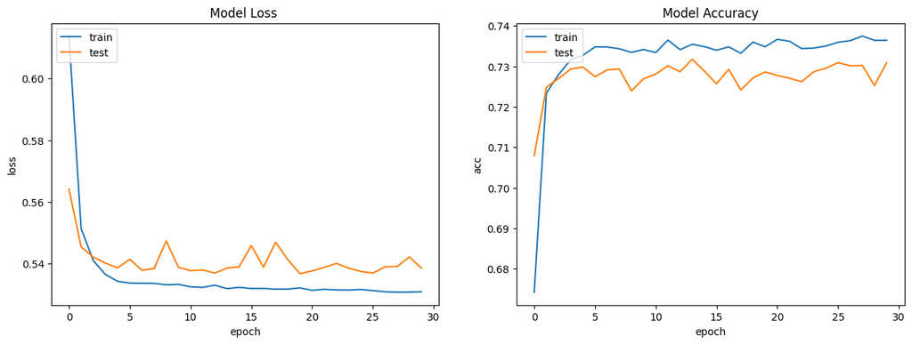

```
Acuracy:  0.7309117317199707
Predicted     0     1    All
Actual
0          4773  2017   6790
1          1687  5288   6975
All        6460  7305  13765
 ************************ Testing ************************
Batch Size :  32
Epoch:  50
```

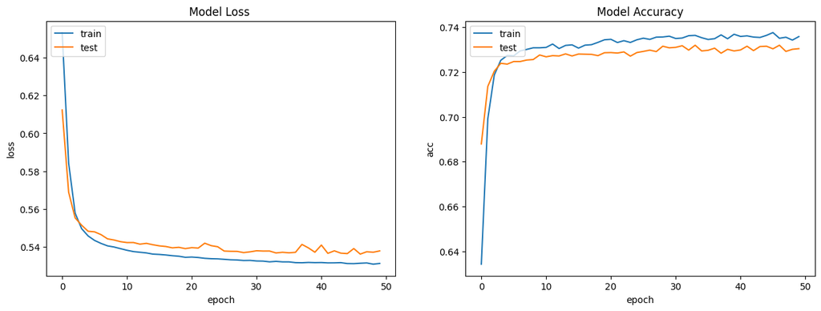

```
Acuracy:  0.7304031848907471
Predicted     0     1    All
Actual
0          4694  2096   6790
1          1615  5360   6975
All        6309  7456  13765
 ************************ Testing ************************
Batch Size :  64
Epoch:  80
```

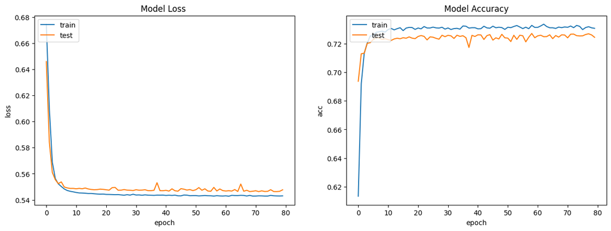

```
Acuracy:  0.7245913743972778
Predicted     0     1    All
Actual
0          4894  1896   6790
1          1895  5080   6975
All        6789  6976  13765
 ************************ Testing ************************
Batch Size :  128
Epoch:  100
```

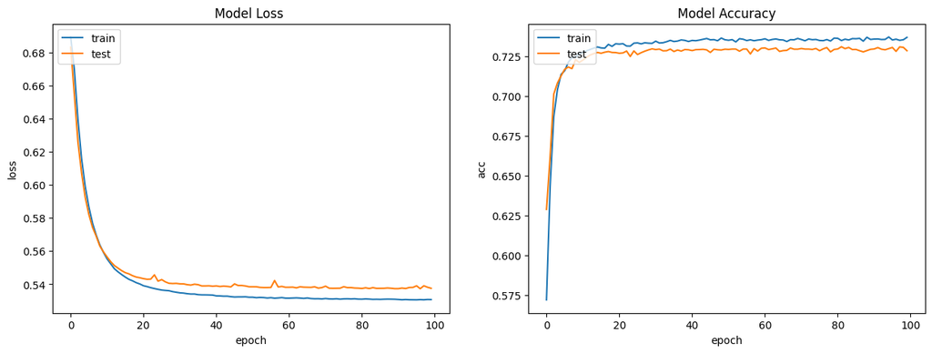

```
Acuracy:  0.7284417152404785
Predicted     0     1    All
Actual
0          4366  2424   6790
1          1314  5661   6975
All        5680  8085  13765
 ************************ Testing ************************
Batch Size :  256
Epoch:  100
```

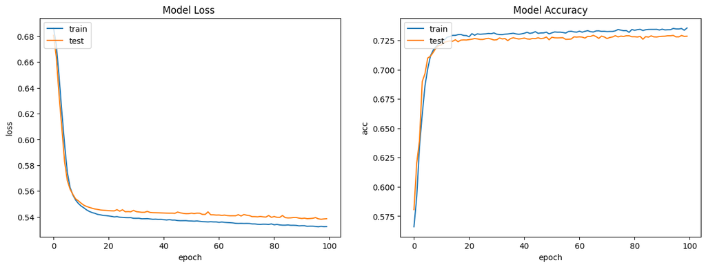

```
Acuracy:  0.7285869717597961
Predicted     0     1    All
Actual
0          4663  2127   6790
1          1609  5366   6975
All        6272  7493  13765
 ************************ Testing ************************
Batch Size :  512
Epoch:  120
```

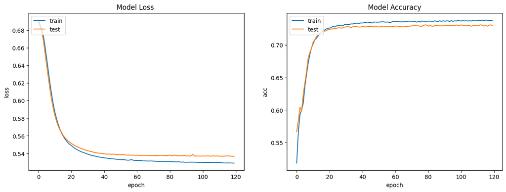

```
Acuracy:  0.729822039604187
Predicted     0     1    All
Actual
0          4483  2307   6790
1          1412  5563   6975
All        5895  7870  13765
 ************************ Testing ************************
Batch Size :  1000
Epoch:  120
```

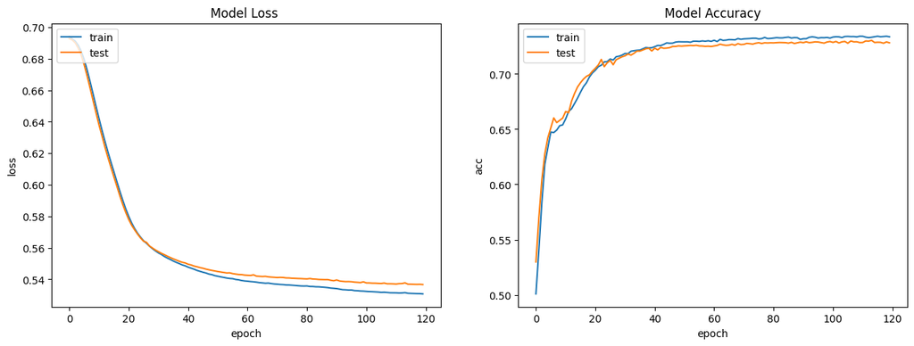

```
Acuracy:  0.7281510829925537
Predicted     0     1    All
Actual
0          4483  2307   6790
1          1435  5540   6975
All        5918  7847  13765
```

```python
seed = 1
np.random.seed(seed)
tf.random.set_seed(seed)

batchesToTest = [1, 8, 32, 64, 128, 256, 512, 1000]
epochToTest = [5, 30, 50, 80, 100, 100, 120, 120]

for index, batchesTest in enumerate(batchesToTest):
    print(" ************************ Testing ************************ ")

    model = Sequential()
    model.add(Dense(5, input_dim = 21, activation='relu'))
    model.add(Dense(3, activation='relu'))
    model.add(Dense(1, activation='sigmoid'))

    model.compile(loss='binary_crossentropy', optimizer="adam", metrics=['acc'])
    results = model.fit(X_train, Y_train, epochs=epochToTest[index], batch_size=batchesToTest[index], verbose=1, validation_data = (X_test, Y_test))

    print("Batch Size : ", batchesToTest[index], "\nEpoch: ", epochToTest[index])
    plot_acc_loss2(results)
    dl_y_pred = (model.predict(X_test) > 0.5).astype("int32")
    dl_y_pred = dl_y_pred.flatten()
    print("Acuracy: ", model.evaluate(X_test,Y_test)[1])
    print(pd.crosstab(Y_test, dl_y_pred, rownames=['Actual'], colnames=['Predicted'], margins=True))
```

#### Trying with different Optimizers

- sgd
- rmspropm
- adagrad
- adam

```
 ************************ Testing SGD ************************
 ************************ Testing RMSPROP ************************
 ************************ Testing ADAGRAD ************************
 ************************ Testing ADAM ************************
```

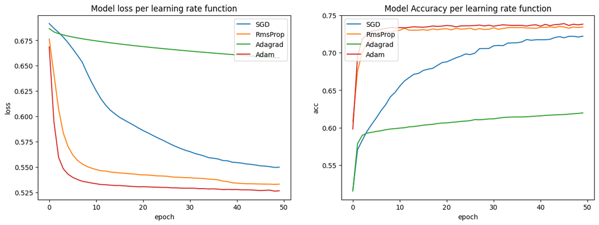

```python
seed = 1
np.random.seed(seed)
tf.random.set_seed(seed)

print(" ************************ Testing SGD ************************ ")
model = Sequential()
model.add(Dense(5, input_dim = 21, activation='relu'))
model.add(Dense(3, activation='relu'))
model.add(Dense(1, activation='sigmoid'))

model.compile(loss='binary_crossentropy', optimizer="sgd", metrics=['acc'])
results_sgd = model.fit(X_train, Y_train, epochs=50, batch_size=32, verbose=1)


print(" ************************ Testing RMSPROP ************************ ")
model = Sequential()
model.add(Dense(5, input_dim = 21, activation='relu'))
model.add(Dense(3, activation='relu'))
model.add(Dense(1, activation='sigmoid'))

model.compile(loss='binary_crossentropy', optimizer="rmsprop", metrics=['acc'])
results_rmspropm = model.fit(X_train, Y_train, epochs=50, batch_size=32, verbose=1)


print(" ************************ Testing ADAGRAD ************************ ")
model = Sequential()
model.add(Dense(5, input_dim = 21, activation='relu'))
model.add(Dense(3, activation='relu'))
model.add(Dense(1, activation='sigmoid'))

model.compile(loss='binary_crossentropy', optimizer="adagrad", metrics=['acc'])
results_adagrad = model.fit(X_train, Y_train, epochs=50, batch_size=32, verbose=1)


print(" ************************ Testing ADAM ************************ ")
model = Sequential()
model.add(Dense(5, input_dim = 21, activation='relu'))
model.add(Dense(3, activation='relu'))
model.add(Dense(1, activation='sigmoid'))

model.compile(loss='binary_crossentropy', optimizer="adam", metrics=['acc'])

results_adam = model.fit(X_train, Y_train, epochs=50, batch_size=32, verbose=1)

# Plotting Loss graph
plt.subplot(1,2,1)
plt.plot(results_sgd.history['loss'])
plt.plot(results_rmspropm.history['loss'])
plt.plot(results_adagrad.history['loss'])
plt.plot(results_adam.history['loss'])
plt.title('Model loss per learning rate function')
plt.ylabel('loss')
plt.xlabel('epoch')
plt.legend(['SGD', 'RmsProp', 'Adagrad', 'Adam'], loc='upper right')

plt.subplot(1,2,2)
plt.plot(results_sgd.history['acc'])
plt.plot(results_rmspropm.history['acc'])
plt.plot(results_adagrad.history['acc'])
plt.plot(results_adam.history['acc'])
plt.title('Model Accuracy per learning rate function')
plt.ylabel('acc')
plt.xlabel('epoch')
plt.legend(['SGD', 'RmsProp', 'Adagrad', 'Adam'], loc='upper left')
plt.show()
```

From the graph above, we can noticed that the "Adagrad" and "SGD" optimizer is not working good, especially "Adagrad" only has around 60% accuracy and has almost 0.67 loss. The "Rmsprop" and "Adam" optimizers have similar accuracy (73%) and loss (0.52).

Hence, I will use the "Rmsprop" and "Adam" for the Grid Search.

#### Regularization Techniques

- Drop out
- Bias / No bias
- Glorot Uniform / Glorot Normal
- Checkpoint + Early Stopping

##### Dropout

```
 ************************ Testing With Dropout ************************
```

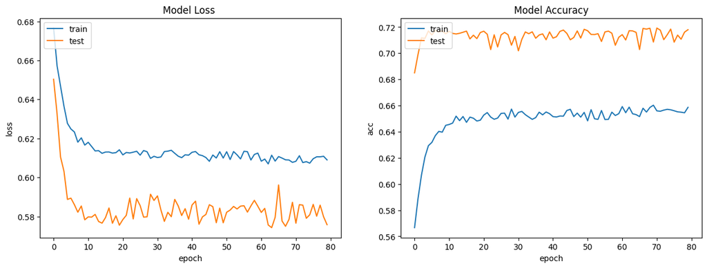

```
Acuracy:  0.7179803848266602
Predicted     0     1    All
Actual
0          4277  2513   6790
1          1369  5606   6975
All        5646  8119  13765
```

```python
seed = 1
np.random.seed(seed)
tf.random.set_seed(seed)

print(" ************************ Testing With Dropout ************************ ")
model = Sequential()
model.add(Dropout(0.2 , input_shape = (21,)))
model.add(Dense(5, activation='relu'))
model.add(Dropout(0.2))
model.add(Dense(3, activation='relu'))
model.add(Dropout(0.2))
model.add(Dense(1, activation='sigmoid'))

model.compile(loss='binary_crossentropy', optimizer="adam", metrics=['acc'])
results = model.fit(X_train, Y_train, epochs=80, batch_size=32, verbose=1, validation_data=(X_test, Y_test))

plot_acc_loss2(results)
dl_y_pred = (model.predict(X_test) > 0.5).astype("int32")
dl_y_pred = dl_y_pred.flatten()
print("Acuracy: ", model.evaluate(X_test,Y_test)[1])
print(pd.crosstab(Y_test, dl_y_pred, rownames=['Actual'], colnames=['Predicted'], margins=True))
```

The first regularization techniques I used is the dropout function. I have set it to 0.2. This is to prevent the model overfitting to the dataset, as we can see from the graph that the accuracy for test dataset is perform better than the training dataset. However, the graph does not look great, so I not gonna use Dropout function in my final modal.

##### Bias / No Bias

```
 ************************ Testing Bias ************************
 ************************ Testing No Bias ************************
```

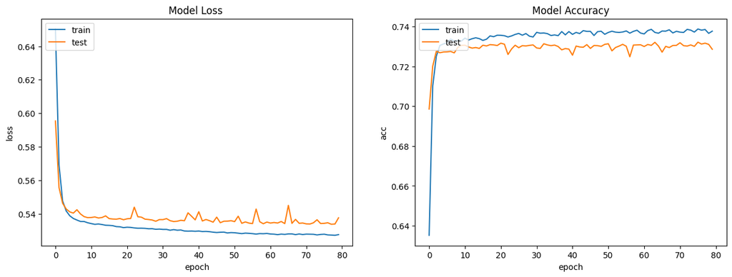

```
Graph for Bias
Acuracy:  0.7285869717597961
Predicted     0     1    All
Actual
0          4959  1831   6790
1          1905  5070   6975
All        6864  6901  13765
```

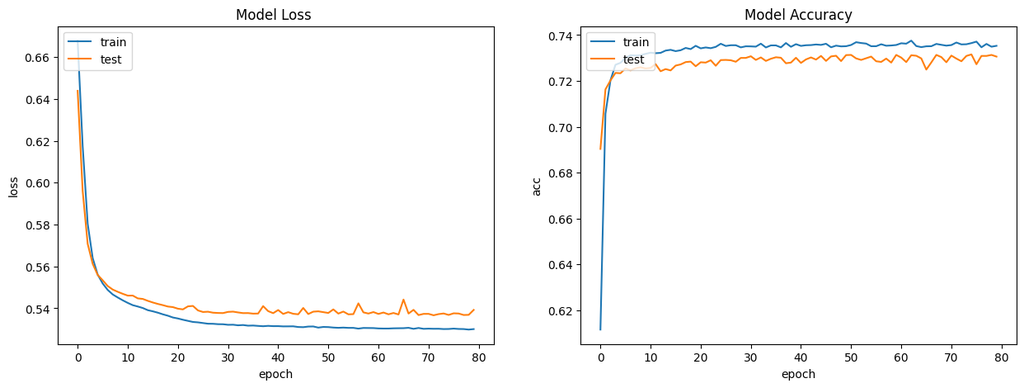

```
Graph for No Bias
Acuracy:  0.7306211590766907
Predicted     0     1    All
Actual
0          4802  1988   6790
1          1720  5255   6975
All        6522  7243  13765
```

```python
seed = 1
np.random.seed(seed)
tf.random.set_seed(seed)

print(" ************************ Testing Bias ************************ ")
model = Sequential()
model.add(Dense(5, input_dim = 21, activation='relu', use_bias = True))
model.add(Dense(3, activation='relu', use_bias = True))
model.add(Dense(1, activation='sigmoid'))

model.compile(loss='binary_crossentropy', optimizer="adam", metrics=['acc'])
results_bias = model.fit(X_train, Y_train, epochs=80, batch_size=32, verbose=1, validation_data=(X_test, Y_test))


print(" ************************ Testing No Bias ************************ ")
model2 = Sequential()
model2.add(Dense(5, input_dim = 21, activation='relu', use_bias = False))
model2.add(Dense(3, activation='relu', use_bias = False))
model2.add(Dense(1, activation='sigmoid'))

model2.compile(loss='binary_crossentropy', optimizer="adam", metrics=['acc'])
results_no_bias = model2.fit(X_train, Y_train, epochs=80, batch_size=32, verbose=1, validation_data=(X_test, Y_test))


plot_acc_loss2(results_bias)
print('Graph for Bias')
dl_y_pred = (model.predict(X_test) > 0.5).astype("int32")
dl_y_pred = dl_y_pred.flatten()
print("Acuracy: ", model.evaluate(X_test,Y_test)[1])
print(pd.crosstab(Y_test, dl_y_pred, rownames=['Actual'], colnames=['Predicted'], margins=True))

plot_acc_loss2(results_no_bias)
print('Graph for No Bias')
dl_y_pred = (model2.predict(X_test) > 0.5).astype("int32")
dl_y_pred = dl_y_pred.flatten()
print("Acuracy: ", model2.evaluate(X_test,Y_test)[1])
print(pd.crosstab(Y_test, dl_y_pred, rownames=['Actual'], colnames=['Predicted'], margins=True))
```

From the graphs and metrices above, I would say that the models worked better when with 'No - Bias' with high accuracy on detecting people who has diabetes. However, I will stick with 'Bias' on my final modal since both of the functions actually has similar accuracy with 73%.

##### Glorot Uniform / Glorot Normal

```
 ************************ Testing Glorot Uniform ************************
 ************************ Testing Glorot Normal ************************
Graph for Uniform
```

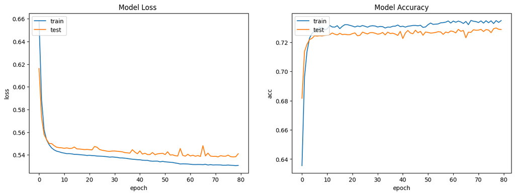

```
Acuracy:  0.7286596298217773
Predicted     0     1    All
Actual
0          4742  2048   6790
1          1687  5288   6975
All        6429  7336  13765
Graph for Normal
```

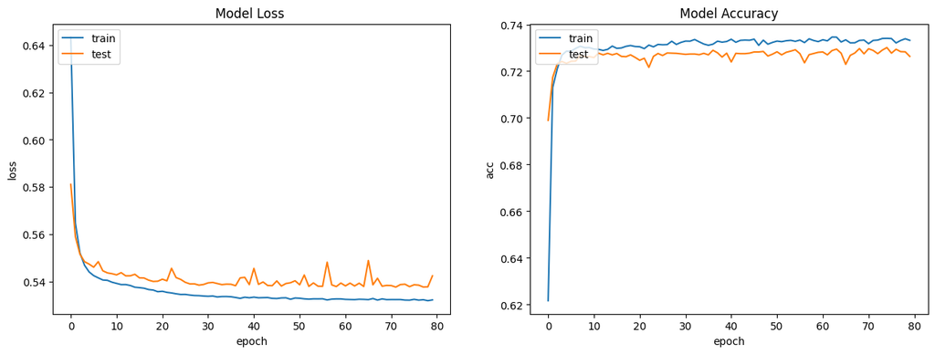

```
Acuracy:  0.7263349294662476
Predicted     0     1    All
Actual
0          4789  2001   6790
1          1766  5209   6975
All        6555  7210  13765
```

```python
seed = 1
np.random.seed(seed)
tf.random.set_seed(seed)

print(" ************************ Testing Glorot Uniform ************************ ")
model = Sequential()
model.add(Dense(5, input_dim = 21, activation='relu', kernel_initializer="GlorotUniform"))
model.add(Dense(3, activation='relu', kernel_initializer="GlorotUniform"))
model.add(Dense(1, activation='sigmoid'))

model.compile(loss='binary_crossentropy', optimizer="adam", metrics=['acc'])
results_uni = model.fit(X_train, Y_train, epochs=80, batch_size=32, verbose=1, validation_data=(X_test, Y_test))


print(" ************************ Testing Glorot Normal ************************ ")
model2 = Sequential()
model2.add(Dense(5, input_dim = 21, activation='relu', kernel_initializer="GlorotNormal"))
model2.add(Dense(3, activation='relu', kernel_initializer="GlorotNormal"))
model2.add(Dense(1, activation='sigmoid'))

model2.compile(loss='binary_crossentropy', optimizer="adam", metrics=['acc'])
results_nor = model2.fit(X_train, Y_train, epochs=80, batch_size=32, verbose=1, validation_data=(X_test, Y_test))

print('Graph for Uniform')
plot_acc_loss2(results_uni)
dl_y_pred = (model.predict(X_test) > 0.5).astype("int32")
dl_y_pred = dl_y_pred.flatten()
print("Acuracy: ", model.evaluate(X_test,Y_test)[1])
print(pd.crosstab(Y_test, dl_y_pred, rownames=['Actual'], colnames=['Predicted'], margins=True))

print('Graph for Normal')
plot_acc_loss2(results_nor)
dl_y_pred = (model2.predict(X_test) > 0.5).astype("int32")
dl_y_pred = dl_y_pred.flatten()
print("Acuracy: ", model2.evaluate(X_test,Y_test)[1])
print(pd.crosstab(Y_test, dl_y_pred, rownames=['Actual'], colnames=['Predicted'], margins=True))
```

##### Checkpoint + Early Stopping

```
 ************************ Testing  Checkpoint + Early Stopping ************************
Epoch 1: acc improved from -inf to 0.59384, saving model to myBest.hdf5
Epoch 2: acc improved from 0.59384 to 0.69374, saving model to myBest.hdf5
Epoch 3: acc improved from 0.69374 to 0.71679, saving model to myBest.hdf5
Epoch 4: acc improved from 0.71679 to 0.72326, saving model to myBest.hdf5
Epoch 5: acc improved from 0.72326 to 0.72709, saving model to myBest.hdf5
Epoch 6: acc improved from 0.72709 to 0.72713, saving model to myBest.hdf5
Epoch 7: acc improved from 0.72713 to 0.72756, saving model to myBest.hdf5
Epoch 8: acc improved from 0.72756 to 0.73038, saving model to myBest.hdf5
Epoch 9: acc did not improve from 0.73038
Epoch 10: acc did not improve from 0.73038
Epoch 11: acc improved from 0.73038 to 0.73070, saving model to myBest.hdf5
Epoch 12: acc improved from 0.73070 to 0.73096, saving model to myBest.hdf5
Epoch 13: acc did not improve from 0.73096
Epoch 14: acc did not improve from 0.73096
Epoch 15: acc improved from 0.73096 to 0.73113, saving model to myBest.hdf5
Epoch 16: acc did not improve from 0.73113
Epoch 17: acc improved from 0.73113 to 0.73135, saving model to myBest.hdf5
Epoch 18: acc improved from 0.73135 to 0.73267, saving model to myBest.hdf5
Epoch 19: acc did not improve from 0.73267
Epoch 20: acc did not improve from 0.73267
Epoch 21: acc did not improve from 0.73267
Epoch 22: acc did not improve from 0.73267
Epoch 23: acc improved from 0.73267 to 0.73307, saving model to myBest.hdf5
Epoch 24: acc did not improve from 0.73307
Epoch 25: acc did not improve from 0.73307
Epoch 26: acc did not improve from 0.73307
Epoch 27: acc did not improve from 0.73307
Epoch 28: acc improved from 0.73307 to 0.73332, saving model to myBest.hdf5
Epoch 29: acc did not improve from 0.73332
Epoch 30: acc did not improve from 0.73332
Epoch 31: acc improved from 0.73332 to 0.73335, saving model to myBest.hdf5
Epoch 32: acc did not improve from 0.73335
Epoch 33: acc did not improve from 0.73335
Epoch 34: acc did not improve from 0.73335
Epoch 35: acc did not improve from 0.73335
Epoch 36: acc did not improve from 0.73335
Epoch 37: acc improved from 0.73335 to 0.73360, saving model to myBest.hdf5
Epoch 38: acc did not improve from 0.73360
Epoch 39: acc improved from 0.73360 to 0.73475, saving model to myBest.hdf5
Epoch 40: acc did not improve from 0.73475
Epoch 41: acc did not improve from 0.73475
Epoch 42: acc did not improve from 0.73475
Epoch 43: acc did not improve from 0.73475
Epoch 44: acc improved from 0.73475 to 0.73486, saving model to myBest.hdf5
Epoch 45: acc did not improve from 0.73486
Epoch 46: acc did not improve from 0.73486
Epoch 47: acc did not improve from 0.73486
Epoch 48: acc improved from 0.73486 to 0.73496, saving model to myBest.hdf5
Epoch 49: acc did not improve from 0.73496
```

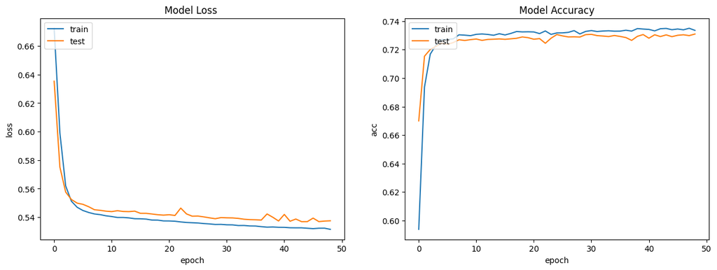

```python
seed = 1
np.random.seed(seed)
tf.random.set_seed(seed)

print(" ************************ Testing  Checkpoint + Early Stopping ************************ ")
model = Sequential()
model.add(Dense(5, input_dim = 21, activation='relu'))
model.add(Dense(3, activation='relu'))
model.add(Dense(1, activation='sigmoid'))

model.compile(loss='binary_crossentropy', optimizer="adam", metrics=['acc'])

checkpoint = ModelCheckpoint("myBest.hdf5", monitor='acc', save_best_only=True, mode="max", verbose=1)
earlystopping = EarlyStopping(monitor="val_loss",patience= 5)
callbacks_list = [checkpoint, earlystopping]

results = model.fit(X_train, Y_train, epochs=80, batch_size=32, verbose=1, callbacks=callbacks_list, validation_data=(X_test, Y_test))
plot_acc_loss2(results)
dl_y_pred = (model.predict(X_test) > 0.5).astype("int32")
dl_y_pred = dl_y_pred.flatten()
print("Acuracy: ", model.evaluate(X_test,Y_test)[1])
print(pd.crosstab(Y_test, dl_y_pred, rownames=['Actual'], colnames=['Predicted'], margins=True))
```

From the verbose above, we know that the early stopping is working as the epoch stop at around 49 even we set it at 80 epcohs.

### Grid search

- best 4 batch sizes
- best 2 optimizers
- 1 weight initializer
- 3 epochs
- early stopping allowed

```python
# Function (Step) of model for training
def gs_model(optimizerIn='adam', initIn='GlorotNormal'):
    model = Sequential()
    model.add(Dense(5, input_dim = 21, activation='relu', kernel_initializer=initIn))
    model.add(Dense(3, activation='relu', kernel_initializer=initIn))
    model.add(Dense(1, activation='sigmoid'))

    model.compile(loss='binary_crossentropy', optimizer=optimizerIn, metrics=['acc'])
    return model
```

```python
seed = 1
np.random.seed(seed)
tf.random.set_seed(seed)

model = KerasClassifier(build_fn=gs_model)

# grid search epochs, batch size and optimizer
batches = [32, 64, 128, 256]
optimizers = ['rmsprop', 'adam']
epochs = [30, 80, 120]

# Checkpointing + Early Stopping
checkpoint = ModelCheckpoint("myBest.hdf5", monitor='acc', save_best_only=True, mode="max", verbose=1)
earlystopping = EarlyStopping(monitor="loss",patience= 3)
callbacks_list = [checkpoint, earlystopping]

param_grid = dict(optimizerIn=optimizers, epochs=epochs, batch_size=batches)

grid = GridSearchCV(estimator=model, param_grid=param_grid)
grid_result = grid.fit(X_train, Y_train, callbacks=callbacks_list)

# summarize results
print("Best: %f using %s" % (grid_result.best_score_, grid_result.best_params_))
means = grid_result.cv_results_['mean_test_score']
stds = grid_result.cv_results_['std_test_score']
params = grid_result.cv_results_['params']

for mean, stdev, param in zip(means, stds, params):
    print("%f (%f) with: %r" % (mean, stdev, param))
```

[output not shown]

[output cut: 1211 more lines]

```
0.744731 (0.005492) with: {'batch_size': 64, 'epochs': 80, 'optimizerIn': 'adam'}
0.741654 (0.006381) with: {'batch_size': 64, 'epochs': 120, 'optimizerIn': 'rmsprop'}
0.744051 (0.003188) with: {'batch_size': 64, 'epochs': 120, 'optimizerIn': 'adam'}
0.646618 (0.110884) with: {'batch_size': 128, 'epochs': 30, 'optimizerIn': 'rmsprop'}
0.737038 (0.007222) with: {'batch_size': 128, 'epochs': 30, 'optimizerIn': 'adam'}
0.741368 (0.003246) with: {'batch_size': 128, 'epochs': 80, 'optimizerIn': 'rmsprop'}
0.743765 (0.002074) with: {'batch_size': 128, 'epochs': 80, 'optimizerIn': 'adam'}
0.744624 (0.003313) with: {'batch_size': 128, 'epochs': 120, 'optimizerIn': 'rmsprop'}
0.694498 (0.094637) with: {'batch_size': 128, 'epochs': 120, 'optimizerIn': 'adam'}
0.736752 (0.004203) with: {'batch_size': 256, 'epochs': 30, 'optimizerIn': 'rmsprop'}
0.687727 (0.089822) with: {'batch_size': 256, 'epochs': 30, 'optimizerIn': 'adam'}
0.697074 (0.091347) with: {'batch_size': 256, 'epochs': 80, 'optimizerIn': 'rmsprop'}
0.741189 (0.003308) with: {'batch_size': 256, 'epochs': 80, 'optimizerIn': 'adam'}
0.742906 (0.004858) with: {'batch_size': 256, 'epochs': 120, 'optimizerIn': 'rmsprop'}
0.741869 (0.002129) with: {'batch_size': 256, 'epochs': 120, 'optimizerIn': 'adam'}
```

### Final Model presentation and performance evaluation

```
 ************************ Final Model Testing ************************
```

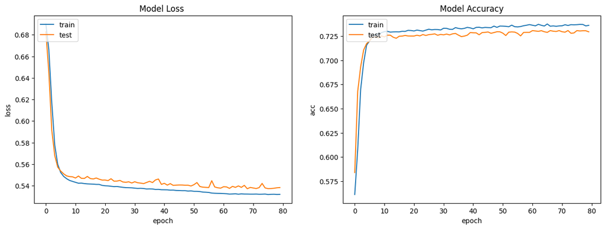

```
Acuracy:  0.7293134927749634
Predicted     0     1    All
Actual
0          4741  2049   6790
1          1677  5298   6975
All        6418  7347  13765
```

```python
seed = 1
np.random.seed(seed)
tf.random.set_seed(seed)


print(" ************************ Final Model Testing ************************ ")
model = Sequential()
model.add(Dense(5, input_dim = 21, activation='relu', kernel_initializer="GlorotNormal"))
model.add(Dense(3, activation='relu'))
model.add(Dense(1, activation='sigmoid'))

model.compile(loss='binary_crossentropy', optimizer="rmsprop", metrics=['acc'])

results = model.fit(X_train, Y_train, epochs=80, batch_size=32, verbose=1, shuffle = True, validation_data=(X_test, Y_test))
plot_acc_loss2(results)
dl_y_pred = (model.predict(X_test) > 0.5).astype("int32")
dl_y_pred = dl_y_pred.flatten()
print("Acuracy: ", model.evaluate(X_test,Y_test)[1])
print(pd.crosstab(Y_test, dl_y_pred, rownames=['Actual'], colnames=['Predicted'], margins=True))
```

### Analysis of performance per class

```python
from sklearn.metrics import classification_report

dl_y_pred = (model.predict(X_test) > 0.5).astype("int32")
report = classification_report(Y_test, dl_y_pred)
print(report)
```

[output not shown]

### Additional Checks for Overfitting

- Using raw data (De-normalizing the data)
- Adding class value as input attribute

```python
test_size = 0.33
# raw data
X_train_raw, X_test_raw, Y_train_raw, Y_test_raw  = train_test_split(X, Y, test_size=test_size, random_state=seed)
```

```
 ************************ Testing for Overfitting ************************
```

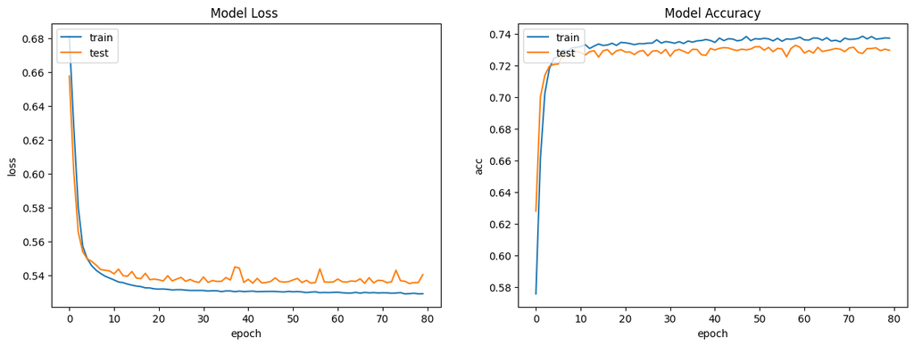

```
********** Performance on normalized data: **********
Acuracy:  72.9458749294281 %


********** Performance on raw un-normalized data: **********
Acuracy:  70.99891304969788 %
```

```python
seed = 1
np.random.seed(seed)
tf.random.set_seed(seed)


print(" ************************ Testing for Overfitting ************************ ")
model = Sequential()
model.add(Dense(5, input_dim = 21, activation='relu', kernel_initializer="GlorotNormal"))
model.add(Dense(3, activation='relu'))
model.add(Dense(1, activation='sigmoid'))

model.compile(loss='binary_crossentropy', optimizer="rmsprop", metrics=['acc'])

results = model.fit(X_train, Y_train, epochs=80, batch_size=32, verbose=1, shuffle = True, validation_data=(X_test, Y_test))
plot_acc_loss2(results)


print("\n\n********** Performance on normalized data: ********** ")
print("Acuracy: ", model.evaluate(X_test,Y_test)[1] *100, "%")

print("\n\n********** Performance on raw un-normalized data: ********** ")
print("Acuracy: ", model.evaluate(X_test_raw,Y_test_raw)[1] *100, "%")
```

### Analysis of performance for target group

- 2 group required

I have choosen the high blood plessure group and Heart Disease Attack Group. I choose these because I'm wondering if the blood pressure will effect diabetes control on people. Besides that, I'm wondering if people is suffering on Diabetes, will they suffer with heart attack disease as well.

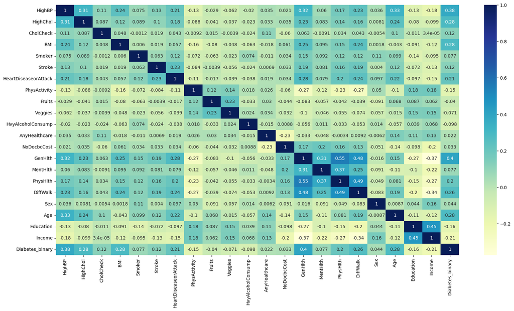

```python
plt.figure(figsize=(20,10))
sns.heatmap(data.corr(), annot=True, cmap="YlGnBu")
```

```python
print(data.columns)
```

```
Index(['HighBP', 'HighChol', 'CholCheck', 'BMI', 'Smoker', 'Stroke',
       'HeartDiseaseorAttack', 'PhysActivity', 'Fruits', 'Veggies',
       'HvyAlcoholConsump', 'AnyHealthcare', 'NoDocbcCost', 'GenHlth',
       'MentHlth', 'PhysHlth', 'DiffWalk', 'Sex', 'Age', 'Education', 'Income',
       'Diabetes_binary'],
      dtype='object')
```

```python
X_train, X_test, Y_train, Y_test  = train_test_split(X, Y, test_size=0.33, random_state=seed, shuffle = True, stratify=(Y))
```

```python
seed = 1
np.random.seed(seed)
tf.random.set_seed(seed)

model = Sequential()
model.add(Dense(5, input_dim = 21, activation='relu', kernel_initializer="GlorotNormal"))
model.add(Dense(3, activation='relu'))
model.add(Dense(1, activation='sigmoid'))

model.compile(loss='binary_crossentropy', optimizer="rmsprop", metrics=['acc'])

results = model.fit(X_train, Y_train, epochs=80, batch_size=32, verbose=0, shuffle = True, validation_data=(X_test, Y_test))
dl_y_pred = (model.predict(X_test) > 0.5).astype("int32")
dl_y_pred = dl_y_pred.flatten()
```

```python
# definition to provide the metrics
def subMetrics(targetGroup, act, pred):
  print("Metrics for: ", targetGroup)
  correct = 0
  # parse both lists to numpy arrays
  act = np.array(act)
  pred = np.array(pred)
  # There may be an easier way to do this, however, I believe it is a manual process!
  for index, item in enumerate(act):
    if item == pred[index]:
      correct += 1
  # print accuracy, and the confusion matrix
  accuracy = round((correct / len(act)) * 100,2)
  print("Accuracy:", accuracy, "%")
  print(pd.crosstab( np.array(act),  np.array(pred), rownames=['Actual'], colnames=['Predicted'], margins=True))
```

```python
# Example for Blood Pressure target groups
bp_pred = []      # High Blood Pressure was label encoded as 1
bp_actual_class = []

bpN_pred = []        # Non-high Blood Pressure was label encoded as 0
bpN_actual_class = []

for index,row in enumerate(X_test_raw):
    if row[0] == 1:
        bp_pred.append(dl_y_pred[index])
        bp_actual_class.append(Y_test[index])
    elif row[0] == 0:
        bpN_pred.append(dl_y_pred[index])
        bpN_actual_class.append(Y_test[index])

# Print the representation of each target group
print("High Blood Pressure instances in the test set:", len(bp_pred))
print("Non-high Blood Pressure instances in the test set:  ", len(bpN_pred))


print("\n"*2)
# Confusion Matrix:
# overall TP, FP, TN, FN values, for binary values only
subMetrics("High Blood Pressure", bp_actual_class, bp_pred)
print("\n")
subMetrics("Non-high Blood Pressure", bpN_actual_class, bpN_pred)
```

```
High Blood Pressure instances in the test set: 7818
Non-high Blood Pressure instances in the test set:   5947



Metrics for:  High Blood Pressure
Accuracy: 74.48 %
Predicted     0     1   All
Actual
0          2763  1085  3848
1           910  3060  3970
All        3673  4145  7818


Metrics for:  Non-high Blood Pressure
Accuracy: 74.89 %
Predicted     0     1   All
Actual
0          2130   812  2942
1           681  2324  3005
All        2811  3136  5947
```

```python
# Example for heart disease group target groups
heart_pred = []      # Heart Diseases was label encoded as 1
heart_actual_class = []

heartN_pred = []        # Non-smoker was label encoded as 0
heartN_actual_class = []

for index,row in enumerate(X_test):
    if row[6] == 1:
        heart_pred.append(dl_y_pred[index])
        heart_actual_class.append(Y_test[index])
    elif row[6] == 0:
        heartN_pred.append(dl_y_pred[index])
        heartN_actual_class.append(Y_test[index])

# Print the representation of each target group
print("Heart Diseases Attack instances in the test set:", len(heart_pred))
print("No Heart Diseases Attack instances in the test set:  ", len(heartN_pred))

print("\n"*2)
# Confusion Matrix:
# overall TP, FP, TN, FN values, for binary values only
subMetrics("Heart Disease Attack", heart_actual_class, heart_pred)
print("\n")
subMetrics("No Heart Disease Attack", heartN_actual_class, heartN_pred)
```

```
Heart Diseases Attack instances in the test set: 2058
No Heart Diseases Attack instances in the test set:   11707



Metrics for:  Heart Disease Attack
Accuracy: 77.11 %
Predicted    0     1   All
Actual
0          111   403   514
1           68  1476  1544
All        179  1879  2058


Metrics for:  No Heart Disease Attack
Accuracy: 74.23 %
Predicted     0     1    All
Actual
0          4782  1494   6276
1          1523  3908   5431
All        6305  5402  11707
```

### Summary and Conclusion

In a conclusion, this deep learning CA aimed to develop a model for predicting diabetes based on the provided dataset. Several experiments were conducted, exploring different network topologies, hyperparameter tuning, and regularization techniques. We also used the GridSearch CV to get the best model after trying with different combination of hyperparameter and techniques. The performance of the models was evaluated by plotting loss and accuracy graph and using confusion metrics which included accuracy, precision, recall, and F1-score.

- batch size: 32
- epoch: 80
- optimizer: RMSPROP
- initializer: Glorot Normal.

From the different testing during the regularization techniques, the dropout function shows that it is helpful to prevent overfitting model. However, it still need to be watch out for underfitting problem might occer. Besides that, the bias / no-bias function had shown that both of the output are very similar, so I had continue the model with bias as it is non ethical if the model no able to accept any outlier. The early stopping helps to prevent wasting memory and times of computer power which is very effective when doing the Grid Search CV function.

```python
%%shell
jupyter nbconvert --to html /content/CA1.ipynb
```

```
[NbConvertApp] Converting notebook /content/CA1.ipynb to html
[NbConvertApp] Writing 3405804 bytes to /content/CA1.html
```